# R Notebook

```r
getwd()
```

```
[1] "C:/Users/UBrisk/Desktop/POSTGRAU-DATA-SCIENCE/CARPETA_APUNTS/TO-GIVE"
```

```r
bank<-read.csv("bank-additional-full.csv",header=T,sep=";", dec=".")
```

We try to build a model with dividing training data and test data set. We divide 75% of whole bank data set as training data, and rest 25% of bank data set.

```r
set.seed(123456789)
random<-sample(1:nrow(bank))
num.bank.training<-as.integer(0.75*length(random))
bank.indices<-random[1:num.bank.training]
train<-bank[bank.indices,]
testing.indices<-random[(num.bank.training+1):length(random)]
testing.set<-bank[testing.indices,]
```

We estimate the full model

```r
logis<-glm(y ~ ., data=train,family=binomial)
summary(logis)
```

```
Call:
glm(formula = y ~ ., family = binomial, data = train)

Deviance Residuals:
    Min       1Q   Median       3Q      Max
-5.9866  -0.2979  -0.1861  -0.1352   3.4223

Coefficients: (1 not defined because of singularities)
                               Estimate Std. Error z value Pr(>|z|)
(Intercept)                  -2.174e+02  4.397e+01  -4.944 7.65e-07
age                          -1.025e-03  2.819e-03  -0.364 0.716046
jobblue-collar               -2.448e-01  9.254e-02  -2.646 0.008149
jobentrepreneur              -1.239e-01  1.429e-01  -0.867 0.385893
jobhousemaid                  2.147e-02  1.706e-01   0.126 0.899825
jobmanagement                -1.058e-01  1.005e-01  -1.053 0.292179
jobretired                    3.925e-01  1.233e-01   3.183 0.001456
jobself-employed             -2.141e-01  1.386e-01  -1.545 0.122364
jobservices                  -1.099e-01  9.866e-02  -1.114 0.265094
jobstudent                    1.178e-01  1.283e-01   0.918 0.358517
jobtechnician                -4.265e-02  8.233e-02  -0.518 0.604415
jobunemployed                 8.525e-02  1.481e-01   0.576 0.564808
jobunknown                   -3.898e-01  2.860e-01  -1.363 0.172791
maritalmarried                9.659e-04  7.926e-02   0.012 0.990277
maritalsingle                 6.066e-02  9.045e-02   0.671 0.502405
maritalunknown                2.576e-01  4.827e-01   0.534 0.593566
educationbasic.6y             1.378e-01  1.388e-01   0.993 0.320921
educationbasic.9y            -4.434e-02  1.107e-01  -0.400 0.688804
educationhigh.school          4.171e-02  1.063e-01   0.392 0.694797
educationilliterate           1.526e+00  7.611e-01   2.004 0.045030
educationprofessional.course  1.464e-01  1.167e-01   1.254 0.209955
educationuniversity.degree    2.017e-01  1.063e-01   1.897 0.057828
educationunknown              2.370e-01  1.358e-01   1.745 0.080983
defaultunknown               -2.665e-01  7.758e-02  -3.435 0.000593
defaultyes                   -7.126e+00  1.392e+02  -0.051 0.959181
housingunknown               -9.014e-03  1.589e-01  -0.057 0.954773
housingyes                   -1.339e-03  4.783e-02  -0.028 0.977666
loanunknown                          NA         NA      NA       NA
loanyes                      -1.025e-01  6.720e-02  -1.526 0.127117
contacttelephone             -6.577e-01  8.880e-02  -7.407 1.30e-13
monthaug                      7.191e-01  1.394e-01   5.160 2.48e-07
```

[output cut: 73 more lines]

```
emp.var.rate                 ***
cons.price.idx               ***
cons.conf.idx                *
euribor3m                    **
nr.employed
---
Signif. codes:  0 ‘***’ 0.001 ‘**’ 0.01 ‘*’ 0.05 ‘.’ 0.1 ‘ ’ 1

(Dispersion parameter for binomial family taken to be 1)

    Null deviance: 21724  on 30890  degrees of freedom
Residual deviance: 12799  on 30838  degrees of freedom
AIC: 12905

Number of Fisher Scoring iterations: 10
```

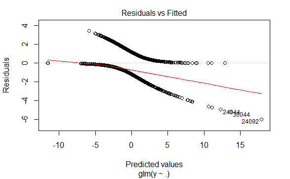

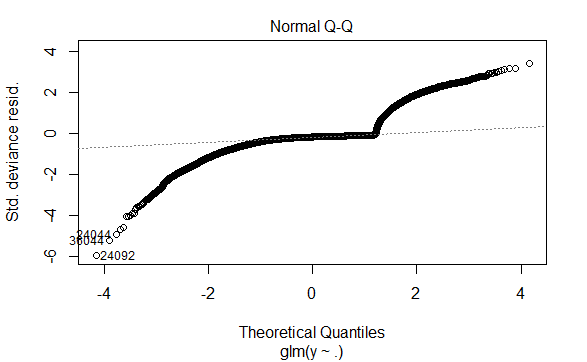

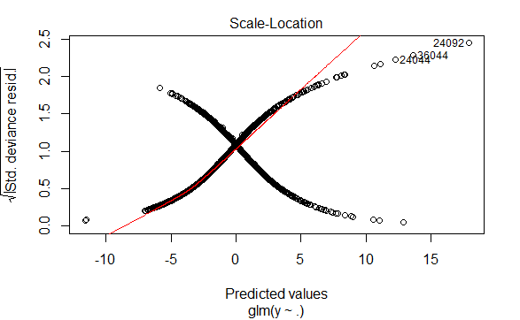

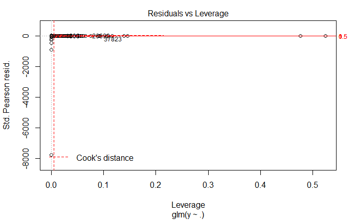

```r
plot(logis)
```

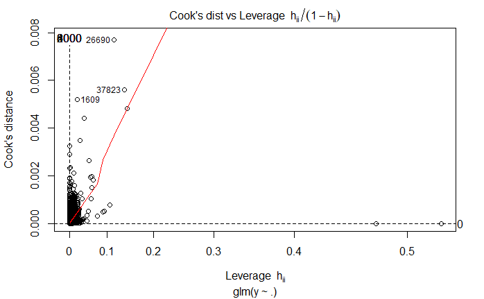

```r
plot(logis,which=6)
```

Boxplot for dependent variable -> however, since y is categorical variable, no need to transformed

[figure not shown]

```r
bank3<-bank2[-c(34743, 40365, 39242),]
logit.2<-glm(y~contact + month + day_of_week + duration + pdays + poutcome + emp.var.rate + cons.price.idx + cons.conf.idx+euribor3m,data=bank3,family=binomial)
summary(logit.2)
```

```
Call:
glm(formula = y ~ contact + month + day_of_week + duration +
    pdays + poutcome + emp.var.rate + cons.price.idx + cons.conf.idx +
    euribor3m, family = binomial, data = bank3)

Deviance Residuals:
    Min       1Q   Median       3Q      Max
-5.8131  -0.0289  -0.0153  -0.0101   2.5200

Coefficients:
                      Estimate Std. Error z value Pr(>|z|)
(Intercept)         -2.457e+02  4.195e+01  -5.858 4.69e-09 ***
contacttelephone    -1.324e+00  3.510e-01  -3.772 0.000162 ***
monthaug             2.816e-01  3.790e-01   0.743 0.457430
monthdec            -3.424e+00  9.607e-01  -3.564 0.000366 ***
monthjul            -1.788e-01  3.899e-01  -0.459 0.646535
monthjun            -1.143e+00  4.591e-01  -2.490 0.012781 *
monthmar             1.469e+00  4.829e-01   3.042 0.002349 **
monthmay            -1.160e+00  3.300e-01  -3.517 0.000437 ***
monthnov            -1.008e+00  4.526e-01  -2.228 0.025898 *
monthoct            -1.150e+00  4.580e-01  -2.511 0.012037 *
monthsep            -9.763e-01  4.588e-01  -2.128 0.033355 *
day_of_weekmon      -9.907e-02  3.044e-01  -0.326 0.744796
day_of_weekthu       4.081e-01  2.799e-01   1.458 0.144862
day_of_weektue       6.887e-01  2.795e-01   2.464 0.013745 *
day_of_weekwed       7.130e-01  2.777e-01   2.567 0.010244 *
duration             5.846e-03  2.305e-04  25.364  < 2e-16 ***
pdays               -1.303e-03  8.480e-04  -1.537 0.124333
poutcomenonexistent  1.574e+00  3.805e-01   4.136 3.53e-05 ***
poutcomesuccess      2.966e+00  7.773e-01   3.815 0.000136 ***
emp.var.rate        -1.592e+00  4.792e-01  -3.322 0.000893 ***
cons.price.idx       2.555e+00  4.355e-01   5.867 4.43e-09 ***
cons.conf.idx        6.327e-02  2.154e-02   2.937 0.003319 **
euribor3m            8.347e-02  3.773e-01   0.221 0.824899
---
Signif. codes:  0 ‘***’ 0.001 ‘**’ 0.01 ‘*’ 0.05 ‘.’ 0.1 ‘ ’ 1

(Dispersion parameter for binomial family taken to be 1)

    Null deviance: 3722.1  on 27762  degrees of freedom
Residual deviance: 1045.5  on 27740  degrees of freedom
AIC: 1091.5

Number of Fisher Scoring iterations: 10
```

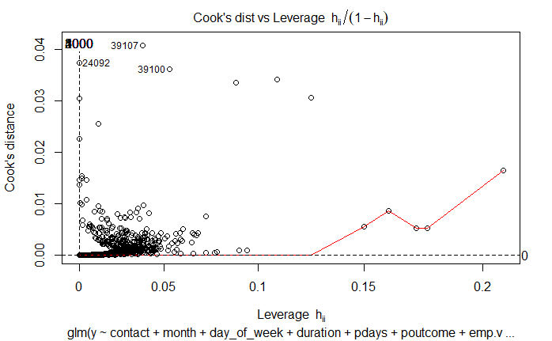

```r
plot(logit.2,which=6)
```

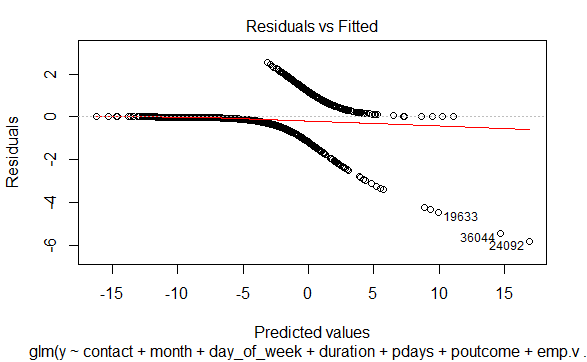

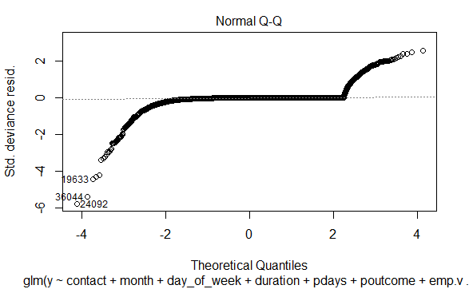

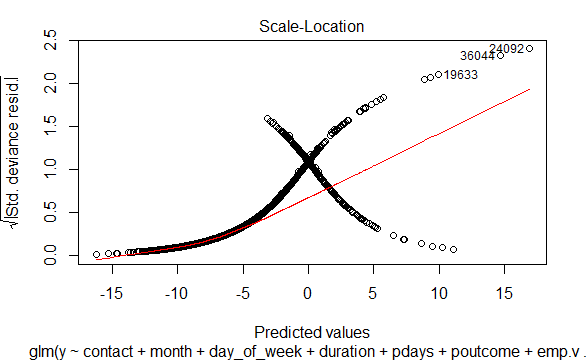

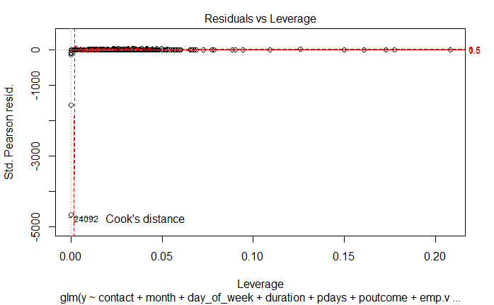

```r
plot(logit.2)
```

Check multicollinearity and variable selection

```r
library("stats")
library("MASS")
stepAIC(logit.2,k=2)
```

```
Start:  AIC=1091.49
y ~ contact + month + day_of_week + duration + pdays + poutcome +
    emp.var.rate + cons.price.idx + cons.conf.idx + euribor3m

                 Df Deviance    AIC
- euribor3m       1   1045.5 1089.5
<none>                1045.5 1091.5
- pdays           1   1047.6 1091.6
- day_of_week     4   1060.2 1098.2
- cons.conf.idx   1   1054.2 1098.2
- emp.var.rate    1   1056.5 1100.5
- contact         1   1061.6 1105.6
- cons.price.idx  1   1080.8 1124.8
- poutcome        2   1088.3 1130.3
- month           9   1112.0 1140.0
- duration        1   2571.2 2615.2

Step:  AIC=1089.54
y ~ contact + month + day_of_week + duration + pdays + poutcome +
    emp.var.rate + cons.price.idx + cons.conf.idx

                 Df Deviance    AIC
<none>                1045.5 1089.5
- pdays           1   1047.6 1089.6
- day_of_week     4   1060.2 1096.2
- cons.conf.idx   1   1055.2 1097.2
- contact         1   1063.1 1105.1
- poutcome        2   1088.3 1128.3
- month           9   1124.3 1150.3
- cons.price.idx  1   1200.6 1242.6
- emp.var.rate    1   1283.6 1325.6
- duration        1   2572.5 2614.5

Call:  glm(formula = y ~ contact + month + day_of_week + duration +
    pdays + poutcome + emp.var.rate + cons.price.idx + cons.conf.idx,
    family = binomial, data = bank3)

Coefficients:
        (Intercept)     contacttelephone             monthaug
         -2.375e+02           -1.296e+00            2.789e-01
           monthdec             monthjul             monthjun
         -3.400e+00           -1.452e-01           -1.088e+00
           monthmar             monthmay             monthnov
          1.424e+00           -1.165e+00           -9.534e-01
           monthoct             monthsep       day_of_weekmon
         -1.117e+00           -9.815e-01           -9.850e-02
     day_of_weekthu       day_of_weektue       day_of_weekwed
          4.073e-01            6.905e-01            7.121e-01
           duration                pdays  poutcomenonexistent
          5.847e-03           -1.303e-03            1.575e+00
    poutcomesuccess         emp.var.rate       cons.price.idx
          2.964e+00           -1.489e+00            2.470e+00
      cons.conf.idx
          6.454e-02

Degrees of Freedom: 27762 Total (i.e. Null);  27741 Residual
Null Deviance:      3722
Residual Deviance: 1046     AIC: 1090
```

From AIC test, the best model would be glm(formula = y ~ contact + month + day_of_week + duration + pdays + poutcome + emp.var.rate + cons.price.idx + cons.conf.idx, family = binomial, data = bank3)

```r
logit.aic<- glm(formula = y ~ contact + month + day_of_week + duration + pdays + poutcome + emp.var.rate + cons.price.idx + cons.conf.idx, family = binomial, data = bank3)
summary(logit.aic)
```

```
Call:
glm(formula = y ~ contact + month + day_of_week + duration +
    pdays + poutcome + emp.var.rate + cons.price.idx + cons.conf.idx,
    family = binomial, data = bank3)

Deviance Residuals:
    Min       1Q   Median       3Q      Max
-5.8136  -0.0289  -0.0152  -0.0100   2.5097

Coefficients:
                      Estimate Std. Error z value Pr(>|z|)
(Intercept)         -2.375e+02  1.915e+01 -12.397  < 2e-16 ***
contacttelephone    -1.296e+00  3.267e-01  -3.968 7.26e-05 ***
monthaug             2.789e-01  3.786e-01   0.737 0.461249
monthdec            -3.400e+00  9.547e-01  -3.562 0.000368 ***
monthjul            -1.452e-01  3.589e-01  -0.405 0.685689
monthjun            -1.088e+00  3.857e-01  -2.821 0.004786 **
monthmar             1.424e+00  4.375e-01   3.254 0.001138 **
monthmay            -1.165e+00  3.291e-01  -3.539 0.000402 ***
monthnov            -9.534e-01  3.785e-01  -2.519 0.011773 *
monthoct            -1.117e+00  4.329e-01  -2.581 0.009865 **
monthsep            -9.815e-01  4.589e-01  -2.139 0.032435 *
day_of_weekmon      -9.850e-02  3.042e-01  -0.324 0.746088
day_of_weekthu       4.073e-01  2.798e-01   1.456 0.145480
day_of_weektue       6.905e-01  2.793e-01   2.472 0.013442 *
day_of_weekwed       7.121e-01  2.776e-01   2.565 0.010322 *
duration             5.847e-03  2.305e-04  25.369  < 2e-16 ***
pdays               -1.303e-03  8.492e-04  -1.534 0.124920
poutcomenonexistent  1.575e+00  3.804e-01   4.141 3.46e-05 ***
poutcomesuccess      2.964e+00  7.784e-01   3.808 0.000140 ***
emp.var.rate        -1.489e+00  1.075e-01 -13.845  < 2e-16 ***
cons.price.idx       2.470e+00  2.062e-01  11.981  < 2e-16 ***
cons.conf.idx        6.454e-02  2.077e-02   3.108 0.001882 **
---
Signif. codes:  0 ‘***’ 0.001 ‘**’ 0.01 ‘*’ 0.05 ‘.’ 0.1 ‘ ’ 1

(Dispersion parameter for binomial family taken to be 1)

    Null deviance: 3722.1  on 27762  degrees of freedom
Residual deviance: 1045.5  on 27741  degrees of freedom
AIC: 1089.5

Number of Fisher Scoring iterations: 10
```

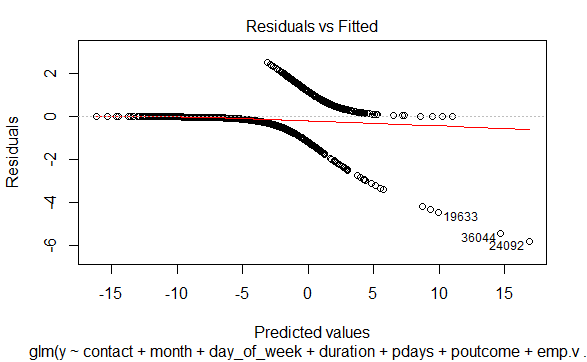

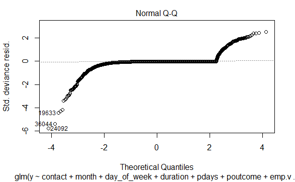

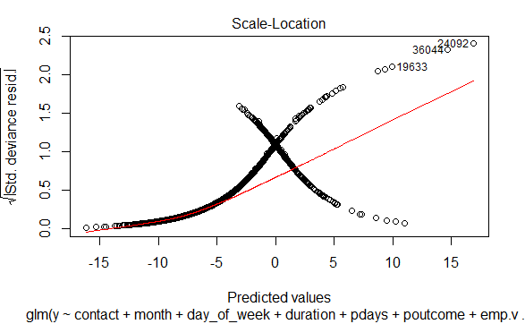

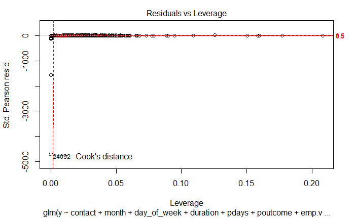

```r
plot(logit.aic)
```

If we use BIC, the function is stepAIC(logit.2,k=log(length(bank3[,1])))

```r
stepAIC(logit.2,k=log(length(bank3[,1])))
```

```
Start:  AIC=1280.81
y ~ contact + month + day_of_week + duration + pdays + poutcome +
    emp.var.rate + cons.price.idx + cons.conf.idx + euribor3m

                 Df Deviance    AIC
- day_of_week     4   1060.2 1254.6
- month           9   1112.0 1255.3
- euribor3m       1   1045.5 1270.6
- pdays           1   1047.6 1272.7
- cons.conf.idx   1   1054.2 1279.3
<none>                1045.5 1280.8
- emp.var.rate    1   1056.5 1281.6
- contact         1   1061.6 1286.7
- poutcome        2   1088.3 1303.2
- cons.price.idx  1   1080.8 1305.9
- duration        1   2571.2 2796.3

Step:  AIC=1254.57
y ~ contact + month + duration + pdays + poutcome + emp.var.rate +
    cons.price.idx + cons.conf.idx + euribor3m

                 Df Deviance    AIC
- month           9   1129.3 1231.6
- euribor3m       1   1060.2 1244.4
- pdays           1   1061.9 1246.1
- cons.conf.idx   1   1068.3 1252.5
<none>                1060.2 1254.6
- emp.var.rate    1   1071.4 1255.5
- contact         1   1076.0 1260.1
- poutcome        2   1104.5 1278.4
- cons.price.idx  1   1095.0 1279.1
- duration        1   2604.7 2788.8

Step:  AIC=1231.6
y ~ contact + duration + pdays + poutcome + emp.var.rate + cons.price.idx +
    cons.conf.idx + euribor3m

                 Df Deviance    AIC
- pdays           1   1131.3 1223.4
- emp.var.rate    1   1131.7 1223.8
```

[output cut: 34 more lines]

```

Call:  glm(formula = y ~ contact + duration + poutcome + cons.price.idx +
    cons.conf.idx + euribor3m, family = binomial, data = bank3)

Coefficients:
        (Intercept)     contacttelephone             duration
         -1.351e+02           -1.514e+00            5.596e-03
poutcomenonexistent      poutcomesuccess       cons.price.idx
          1.337e+00            3.990e+00            1.425e+00
      cons.conf.idx            euribor3m
          1.075e-01           -1.026e+00

Degrees of Freedom: 27762 Total (i.e. Null);  27755 Residual
Null Deviance:      3722
Residual Deviance: 1134     AIC: 1150
```

From BIC test the best model would be glm(formula = y ~ contact + duration + poutcome + cons.price.idx + cons.conf.idx + euribor3m, family = binomial, data = bank3)

```r
logit.bic<-glm(formula = y ~ contact + duration + poutcome + cons.price.idx + cons.conf.idx + euribor3m, family = binomial, data = bank3)
summary(logit.bic)
```

```
Call:
glm(formula = y ~ contact + duration + poutcome + cons.price.idx +
    cons.conf.idx + euribor3m, family = binomial, data = bank3)

Deviance Residuals:
    Min       1Q   Median       3Q      Max
-5.6603  -0.0378  -0.0188  -0.0137   2.5122

Coefficients:
                      Estimate Std. Error z value Pr(>|z|)
(Intercept)         -1.351e+02  1.321e+01 -10.226  < 2e-16 ***
contacttelephone    -1.514e+00  2.961e-01  -5.114 3.15e-07 ***
duration             5.596e-03  2.105e-04  26.592  < 2e-16 ***
poutcomenonexistent  1.337e+00  3.410e-01   3.921 8.80e-05 ***
poutcomesuccess      3.990e+00  3.500e-01  11.400  < 2e-16 ***
cons.price.idx       1.425e+00  1.443e-01   9.875  < 2e-16 ***
cons.conf.idx        1.075e-01  1.563e-02   6.875 6.18e-12 ***
euribor3m           -1.026e+00  7.503e-02 -13.671  < 2e-16 ***
---
Signif. codes:  0 ‘***’ 0.001 ‘**’ 0.01 ‘*’ 0.05 ‘.’ 0.1 ‘ ’ 1

(Dispersion parameter for binomial family taken to be 1)

    Null deviance: 3722.1  on 27762  degrees of freedom
Residual deviance: 1133.8  on 27755  degrees of freedom
AIC: 1149.8

Number of Fisher Scoring iterations: 10
```

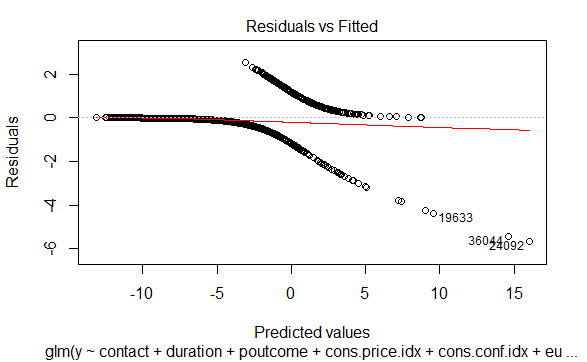

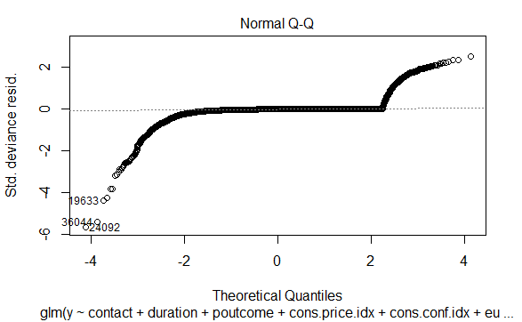

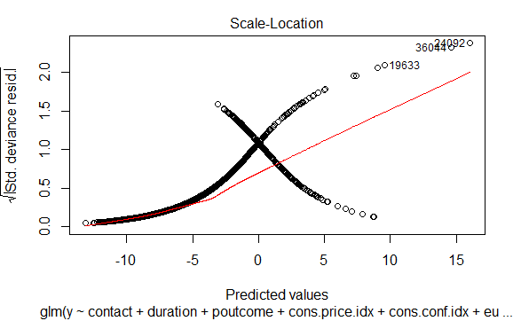

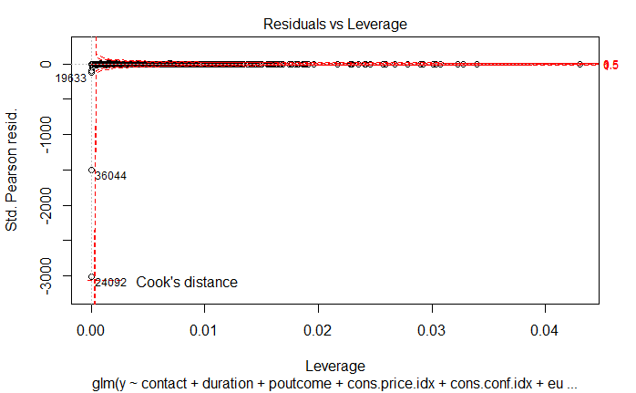

```r
plot(logit.bic)
```

Let’s do the predictions now:

```r
prediction <- data.frame(predict(logit.bic,bank3,type="response"))
prediction[prediction<0.5]=0
prediction[prediction>=0.5]=1
predictions <- data.frame(Prediction = as.numeric(prediction[,1]),Actual = as.numeric(bank3$y)-1)
predictions$Correct <- (predictions$Actual == predictions$Prediction)
logistic_accuracy<-table(predictions$Correct)/length(predictions$Correct)*100
logistic_accuracy
```

```
     FALSE       TRUE
 0.8572561 99.1427439
```

The accuracy is 99.14% which is really high.

```r
prediction.test<-data.frame(predict(logit.bic,testing.set,type="response"))
prediction.test[prediction.test<0.5]=0
prediction.test[prediction.test>=0.5]=1
predictions.test <- data.frame(Prediction = as.numeric(prediction.test[,1]),Actual = as.numeric(testing.set$y)-1)
predictions.test$Correct <- (predictions.test$Actual == predictions.test$Prediction)
logistic_accuracy.test<-table(predictions.test$Correct)/length(predictions.test$Correct)*100
logistic_accuracy.test
```

```
   FALSE     TRUE
10.84782 89.15218
```

The accuracy is 89.15% which is less than prediction of training.set.

Next one would be decision tree model

```r
#install.packages("ElemStatLearn")
#install.packages("tree")
#install.packages("rpart")
#install.packages("rattle")
#install.packages("rpart.plot")
#install.packages("RcolorBrewer")

library(ElemStatLearn)
library(tree)
require(rpart)
library(rpart)
tree <- rpart(y~contact + duration + poutcome + cons.price.idx +
                cons.conf.idx + euribor3m, data=bank3, method="class")
library(rattle)
library(rpart.plot)
library(RColorBrewer)
fancyRpartPlot(tree,main = "", sub = "",cex=0.5)
printcp(tree)
plotcp(tree)
# visualize cross-validation results
# With the plot of CP, I select threshold cp as 0.0195
# Next, I prune my tree model to avoid over-fitting
tree.prune = prune(tree, cp = 0.0195)
fancyRpartPlot(tree.prune,main = "", sub = "",cex=0.5)
```

[output not shown]

Make prediction

```r
prediction.tree <- data.frame(predict(tree.prune, bank3, type = "class"))
predictions.tree <- data.frame(Prediction = as.numeric(prediction.tree[,1])-1,Actual = as.numeric(bank3$y)-1)
predictions.tree$Correct <- (predictions.tree$Actual == predictions.tree$Prediction)
Tree_Accuracy <- table(predictions.tree$Correct)/length(predictions.tree$Correct)*100
Tree_Accuracy
```

```
     FALSE       TRUE
 0.7023737 99.2976263
```

predict with test

```r
prediction.tree.test<-data.frame(predict(tree.prune,testing.set,
     type="class"))
predictions.tree.t <- data.frame(Prediction = as.numeric(prediction.tree.test[,1])-1,Actual = as.numeric(testing.set$y)-1)
predictions.tree.t$Correct <- (predictions.tree.t$Actual == predictions.tree.t$Prediction)
Tree_Accuracy.t <- table(predictions.tree.t$Correct)/length(predictions.tree.t$Correct)*100
Tree_Accuracy.t
```

```
   FALSE     TRUE
10.73128 89.26872
```

Random Forrest

```r
library(randomForest)
forest<-randomForest(as.factor(y)~contact + duration + poutcome + cons.price.idx +
                       cons.conf.idx + euribor3m,data=bank2, importance=TRUE, ntree=100)
#nstead of specifying method="class" as with rpart, we force the model
#to predict our classification by temporarily changing our target
#variable to a factor with only two levels using as.factor(). The
#importance=TRUE argument allows us to inspect variable importance
#as we'll see, and the ntree argument specifies how many trees we want to grow.
#If you were working with a larger dataset you may want to reduce
#the number of trees, at least for initial exploration, or restrict the complexity
#of each tree using nodesize as well as reduce the number of rows sampled with
#sampsize. You can also override the default number of variables to choose
#from with mtry, but the default is the square root of the total number
#available and that should work just fine. Since we only have a small
#dataset to play with, we can grow a large number of trees and not worry
#too much about their complexity, it will still run pretty fast.
summary(forest)
```

```
                Length Class  Mode
call                5  -none- call
type                1  -none- character
predicted       27763  factor numeric
err.rate          300  -none- numeric
confusion           6  -none- numeric
votes           55526  matrix numeric
oob.times       27763  -none- numeric
classes             2  -none- character
importance         24  -none- numeric
importanceSD       18  -none- numeric
localImportance     0  -none- NULL
proximity           0  -none- NULL
ntree               1  -none- numeric
mtry                1  -none- numeric
forest             14  -none- list
y               27763  factor numeric
test                0  -none- NULL
inbag               0  -none- NULL
terms               3  terms  call
```

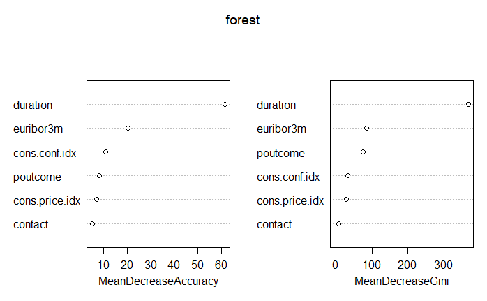

```r
varImpPlot(forest)
```

```r
#There's two types of importance measures shown above.
#The accuracy one tests to see how worse the model
#performs without each variable, so a high decrease
#in accuracy would be expected for very predictive variables.
#The Gini one digs into the mathematics behind decision trees,
#but essentially measures how pure the nodes are at the end of the tree.
#Again it tests to see the result if each variable is taken out and
#a high score means the variable was important.
```

Make prediction

```r
prediction.forest <- data.frame(predict(forest, bank2, type = "class"))
predictions.forest <- data.frame(Prediction = as.numeric(prediction.forest[,1])-1,Actual = as.numeric(bank2$y)-1)
predictions.forest$Correct <- (predictions.forest$Actual == predictions.forest$Prediction)
forest_Accuracy <- table(predictions.forest$Correct)/length(predictions.forest$Correct)*100
forest_Accuracy
```

```
    FALSE      TRUE
 0.129669 99.870331
```

predict with test

```r
prediction.forest.test<-data.frame(predict(forest,testing.set,type="class"))
predictions.forest.t <- data.frame(Prediction = as.numeric(prediction.forest.test[,1])-1,Actual = as.numeric(testing.set$y)-1)
predictions.forest.t$Correct <- (predictions.forest.t$Actual == predictions.forest.t$Prediction)
Tree_Accuracy.t <- table(predictions.forest.t$Correct)/length(predictions.forest.t$Correct)*100
Tree_Accuracy.t
```

```
   FALSE     TRUE
10.65359 89.34641
```

# Suport vector machine

Support vector machine

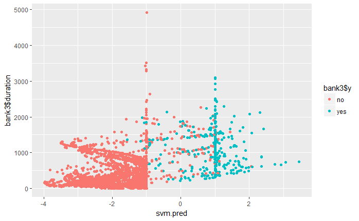

```r
#install.packages("e1071")
#install.packages("kernlab")
library(e1071)
library(kernlab)
#bank3$ynum=(bank3$y=='yes')*1+0
svm.fit = ksvm(y~ contact + duration + poutcome + cons.price.idx +
                       cons.conf.idx + euribor3m, data = bank3, type="C-svc", kernel="rbfdot", C=10)
svm.pred <- predict(svm.fit, bank3, type = "decision")
library(ggplot2)
qplot(svm.pred, bank3$duration, color=bank3$y)
```

```r
summary(svm.fit)
```

```
Length  Class   Mode
     1   ksvm     S4
```

Make prediction

```r
prediction.svm <- data.frame(predict(svm.fit, bank3))
predictions.svm <- data.frame(Prediction = as.numeric(prediction.svm[,1])-1,Actual = as.numeric(bank3$y)-1)
predictions.svm$Correct <- (predictions.svm$Actual == predictions.svm$Prediction)
svm_Accuracy <- table(predictions.svm$Correct)/length(predictions.svm$Correct)*100
svm_Accuracy
```

```
     FALSE       TRUE
 0.3926089 99.6073911
```

predict with test

```r
prediction.svm.test<-data.frame(predict(svm.fit,testing.set))
predictions.svm.t <- data.frame(Prediction = as.numeric(prediction.svm.test[,1])-1,Actual = as.numeric(testing.set$y)-1)
predictions.svm.t$Correct <- (predictions.svm.t$Actual == predictions.svm.t$Prediction)
svm_Accuracy.t <- table(predictions.svm.t$Correct)/length(predictions.svm.t$Correct)*100
svm_Accuracy.t
```

```
   FALSE     TRUE
10.69243 89.30757
```